# Text Analyis

# Your mission

Perform text analysis.

## Okay, I need more information

Perform sentiment analysis or topic modeling using text analysis methods as demonstrated in the pre-class work and in the readings.

## Okay, I need even more information.

Do the above. Can’t think of a data source?

- `gutenbergr`
- `AssociatedPress` from the `topicmodels` package
- `NYTimes` or `USCongress` from the `RTextTools` package
- Harry Potter Complete 7 Books text
- [State of the Union speeches](https://pradeepadhokshaja.wordpress.com/2017/03/31/scraping-the-web-for-presdential-inaugural-addresses-using-rvest/)
- Scrape tweets using [`twitteR`](https://www.credera.com/blog/business-intelligence/twitter-analytics-using-r-part-1-extract-tweets/)

Analyze the text for sentiment OR topic. **You do not need to do both**. The datacamp courses and [Tidy Text Mining with R](http://tidytextmining.com/) are good starting points for templates to perform this type of analysis, but feel free to *expand beyond these examples*.

# Timelines and Task

We will spend the next 2 weeks working on analyzing textual data in R. You will do the following:

- Start with some text based data.
- Clean data and prepare it for analysis
- Ask questions about the data
- Answer these questions with the data using tables and graphics
- Each group member must have their own unique question that they code the answer for.

# Cleaning the data

```r
book
```

```
## # A tibble: 409,338 x 4
## # Groups:   word [23,795]
##    chapter     word              title series
##      <int>    <chr>              <chr>  <int>
##  1       1 treating chamber_of_secrets      1
##  2       1    curse chamber_of_secrets      1
##  3       1  treated chamber_of_secrets      1
##  4       1  wizards chamber_of_secrets      1
##  5       1  wizards chamber_of_secrets      1
##  6       1  wizards chamber_of_secrets      1
##  7       1  wearing chamber_of_secrets      1
##  8       1   wiggly chamber_of_secrets      1
##  9       1 savagely chamber_of_secrets      1
## 10       1   bolted chamber_of_secrets      1
## # ... with 409,328 more rows
```

# Questions for analysis:

1. By ordering the frequency of the word that appears(remove stop words), could you find the word that appears most frequently?

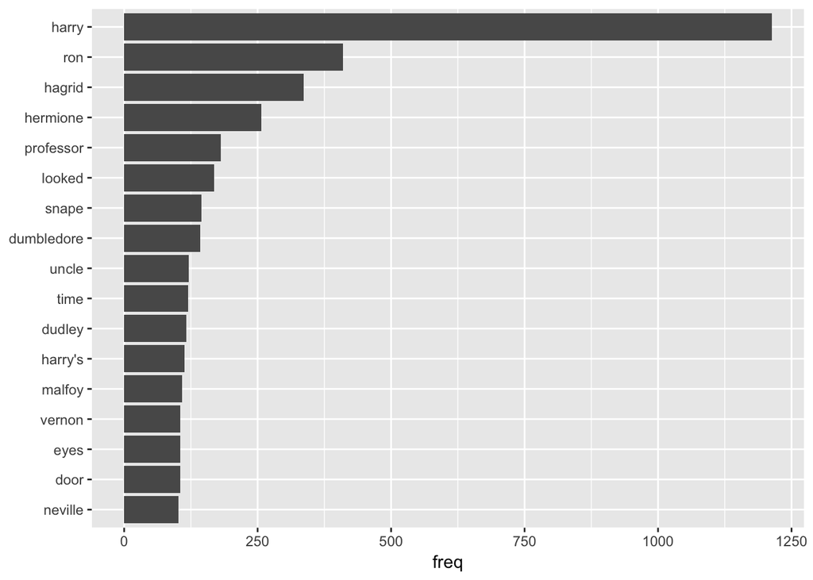

```r
tidy_freq
```

2. By doing sentiment analysis, which sentiment word is most likely to be used by author?

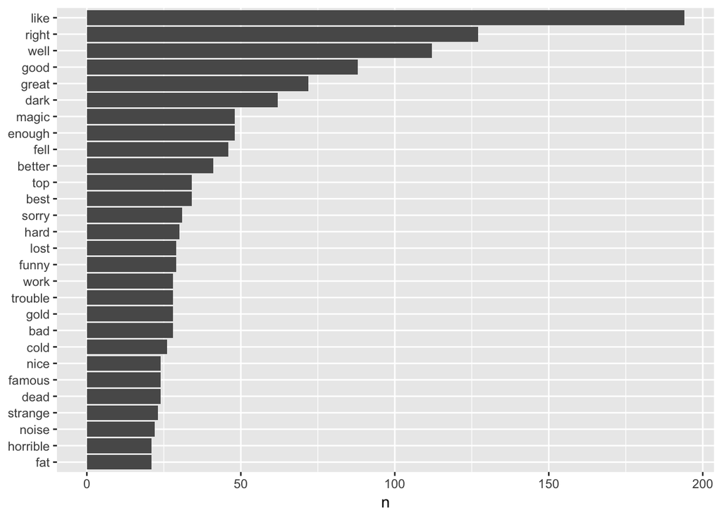

```r
sentiment_likely
```

3. By dividing into two groups, which word is used most frequently in each group?

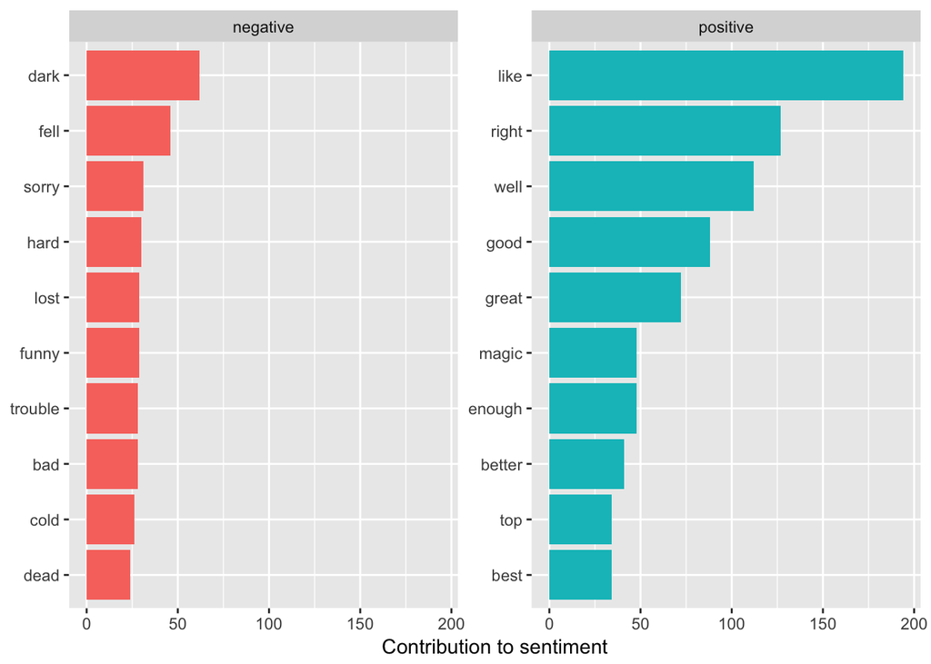

```r
bing_freq
```

```r
tidy_stone2
```

[output not shown]

5. Can you draw a picture of the percentage of the word?

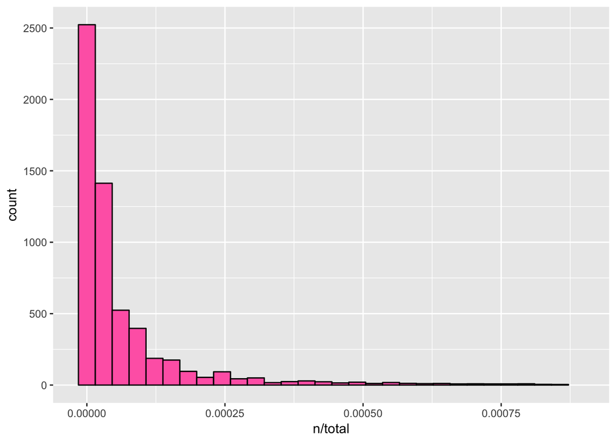

```r
stone_word2
```

6. What is the relationship between the rank and frequency?

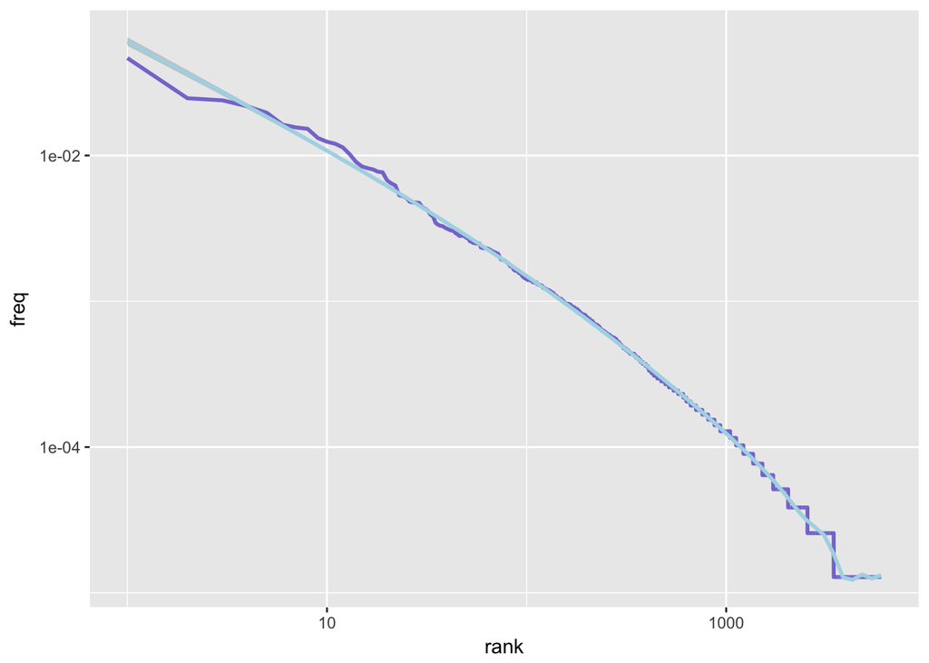

```r
freq_by_rank
```

7. Could you divide the text by bigrams rather than words?

```r
bigram_counts
```

```
## # A tibble: 7,695 x 3
##        word1      word2     n
##        <chr>      <chr> <int>
##  1     uncle     vernon    97
##  2 professor mcgonagall    90
##  3      aunt    petunia    52
##  4     harry     potter    26
##  5     harry     looked    22
##  6 professor dumbledore    20
##  7 professor   quirrell    18
##  8  hermione    granger    16
##  9    privet      drive    16
## 10 professor   flitwick    15
## # ... with 7,685 more rows
```

```r
bigram_united
```

```
## # A tibble: 9,487 x 2
##     line           bigram
##  * <int>            <chr>
##  1     1     privet drive
##  2     1 perfectly normal
##  3     1      firm called
##  4     1 called grunnings
##  5     1     usual amount
##  6     1     time craning
##  7     1    garden fences
##  8     1    fences spying
##  9     1       son called
## 10     1    called dudley
## # ... with 9,477 more rows
```

8. What is the tf_idf of the bigram_united we create in last question?

```r
bigram_tf_idf
```

```
## # A tibble: 8,652 x 6
##     line           bigram     n         tf       idf     tf_idf
##    <int>            <chr> <int>      <dbl>     <dbl>      <dbl>
##  1     3     uncle vernon    46 0.08778626 0.8873032 0.07789303
##  2     2     aunt petunia    22 0.05597964 0.7537718 0.04219588
##  3     3   smelting stick     7 0.01335878 2.8332133 0.03784827
##  4     2     uncle vernon    16 0.04071247 0.8873032 0.03612430
##  5     4     uncle vernon    17 0.03617021 0.8873032 0.03209395
##  6    11     marcus flint     5 0.01072961 2.8332133 0.03039928
##  7    13 sorcerer's stone     8 0.02094241 1.4469190 0.03030197
##  8     1   shooting stars     5 0.01014199 2.8332133 0.02873442
##  9     3     aunt petunia    19 0.03625954 0.7537718 0.02733142
## 10     3   uncle vernon's     7 0.01335878 1.7346011 0.02317215
## # ... with 8,642 more rows
```

9. Can you show the word after the negative word?

```r
not_words
```

```
## # A tibble: 21 x 3
##       word2 score     n
##       <chr> <int> <int>
##  1      bad    -3     1
##  2   bother    -2     1
##  3    brave     2     1
##  4 careless    -2     1
##  5   daring     2     1
##  6     easy     1     1
##  7  forgive     1     1
##  8    funny     4     1
##  9     hurt    -2     1
## 10      ill    -2     1
## # ... with 11 more rows
```

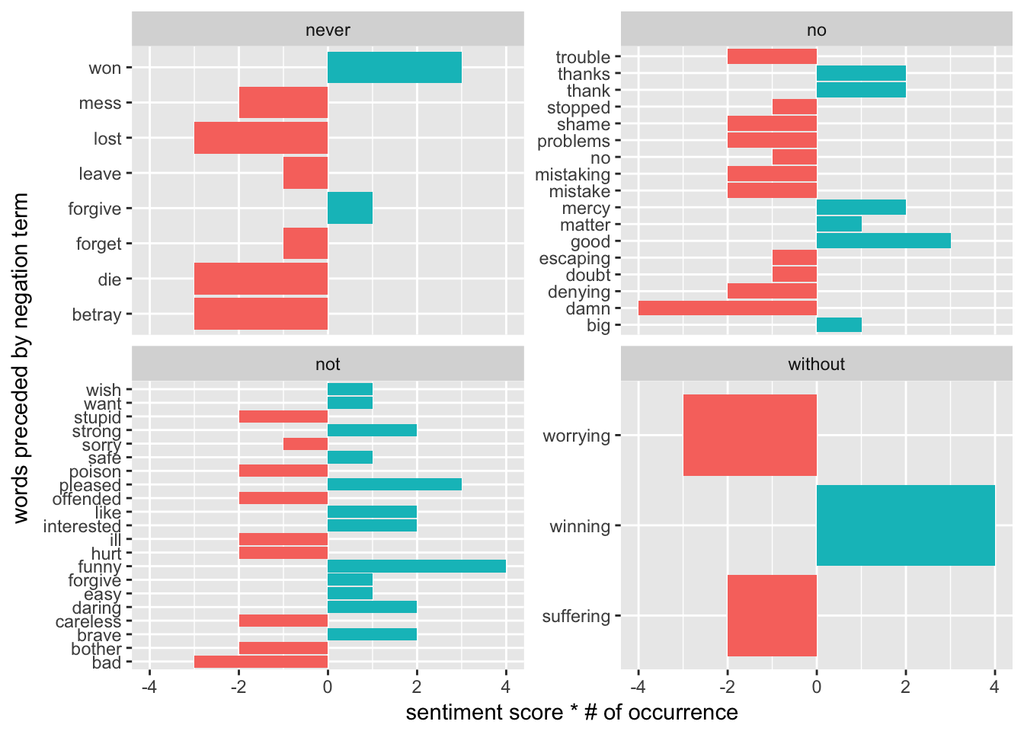

```r
negated_words
```

10. Draw the picture of the relationship between different words, using arrows to show the relation.

```r
bigram_graph
```

```
## IGRAPH 0ab5572 DN-- 67 44 --
## + attr: name (v/c), n (e/n)
## + edges from 0ab5572 (vertex names):
##  [1] uncle       ->vernon     professor   ->mcgonagall
##  [3] aunt        ->petunia    harry       ->potter
##  [5] harry       ->looked     professor   ->dumbledore
##  [7] professor   ->quirrell   hermione    ->granger
##  [9] privet      ->drive      professor   ->flitwick
## [11] invisibility->cloak      harry       ->told
## [13] nicolas     ->flamel     harry       ->ron
## [15] madam       ->pomfrey    sorcerer's  ->stone
## + ... omitted several edges
```

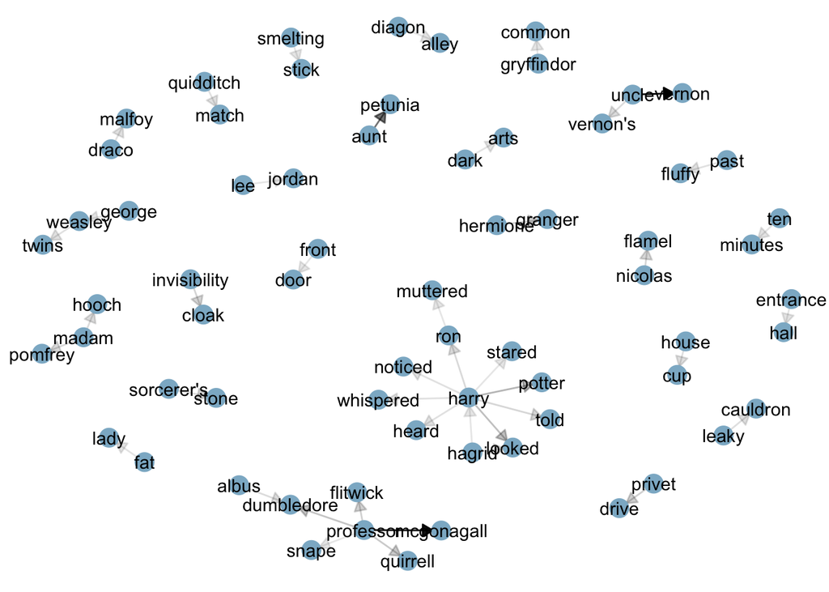

```r
bigram_ggraph
```

11. What is the correlation between each word?

```r
word_cor
```

```
## # A tibble: 295,392 x 3
##       item1    item2 correlation
##       <chr>    <chr>       <dbl>
##  1   vernon    uncle   0.9974725
##  2    uncle   vernon   0.9974725
##  3  petunia   dudley   0.9954576
##  4   dudley  petunia   0.9954576
##  5      yeh      ter   0.9911646
##  6      ter      yeh   0.9911646
##  7 cupboard  petunia   0.9898987
##  8  petunia cupboard   0.9898987
##  9    ronan  unicorn   0.9824679
## 10  unicorn    ronan   0.9824679
## # ... with 295,382 more rows
```

12. What are the top words appear in each of the book?

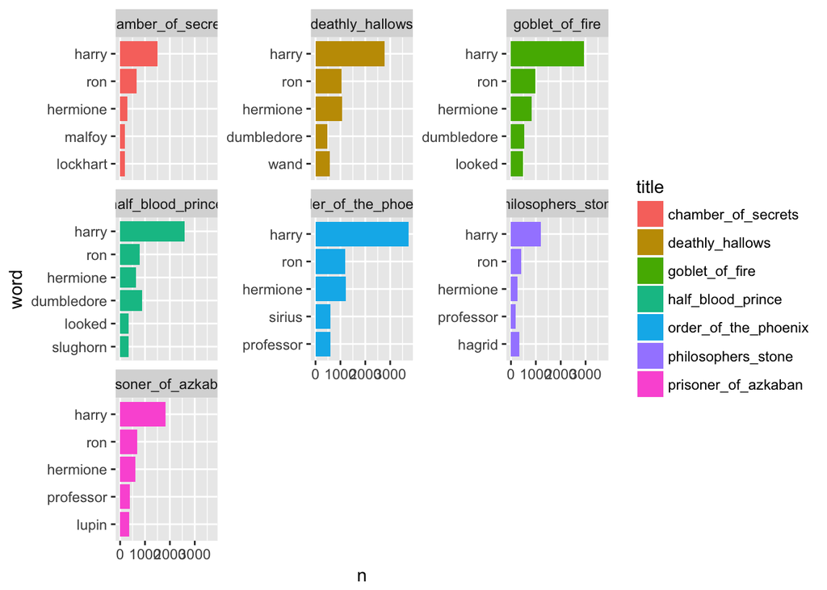

```r
top_book
```

13. Dividing by books, what is the top joy words in each of them?

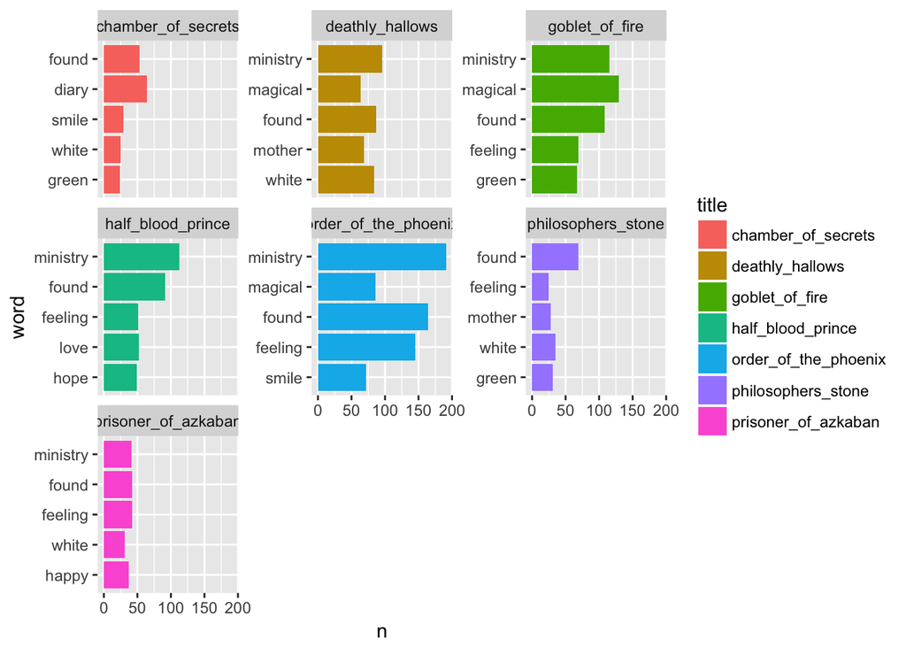

```r
top_joy_book
```

14. Dividing by books, what is the top “sadness” words in each of them?

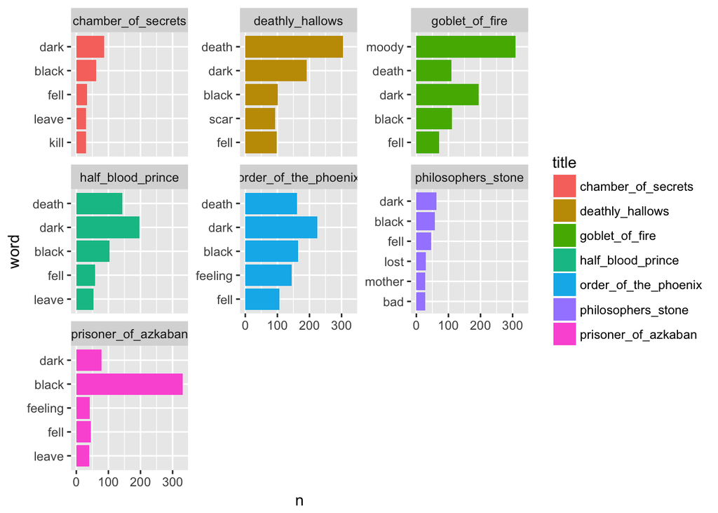

```r
top_sad_book
```

15. What is the ratio of the positive word and negative word in each book according to the chapter?

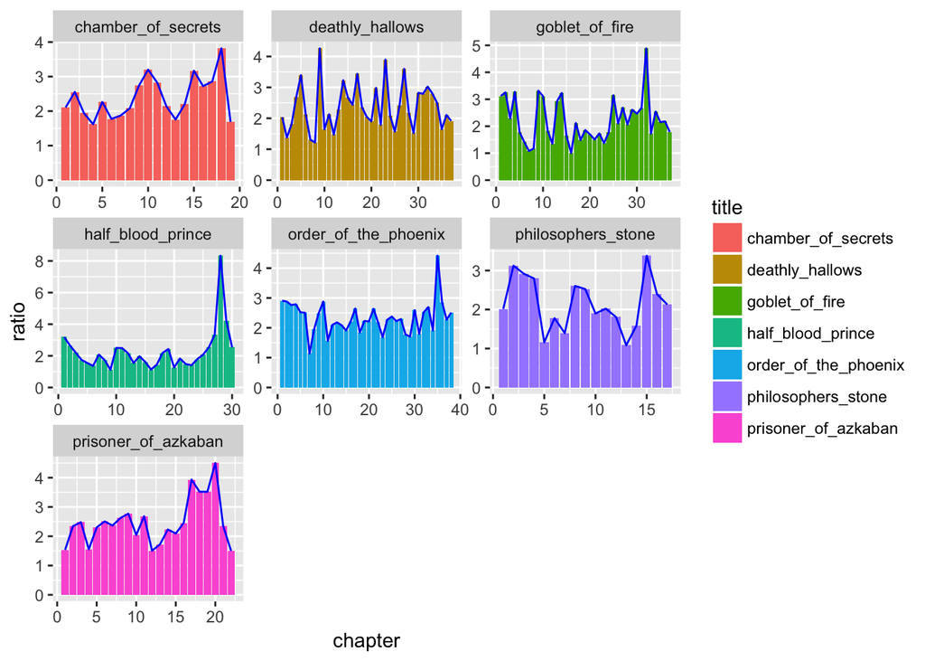

```r
ratio
```

16. What is the difference of negative words and positive words in each book according to the chapter?

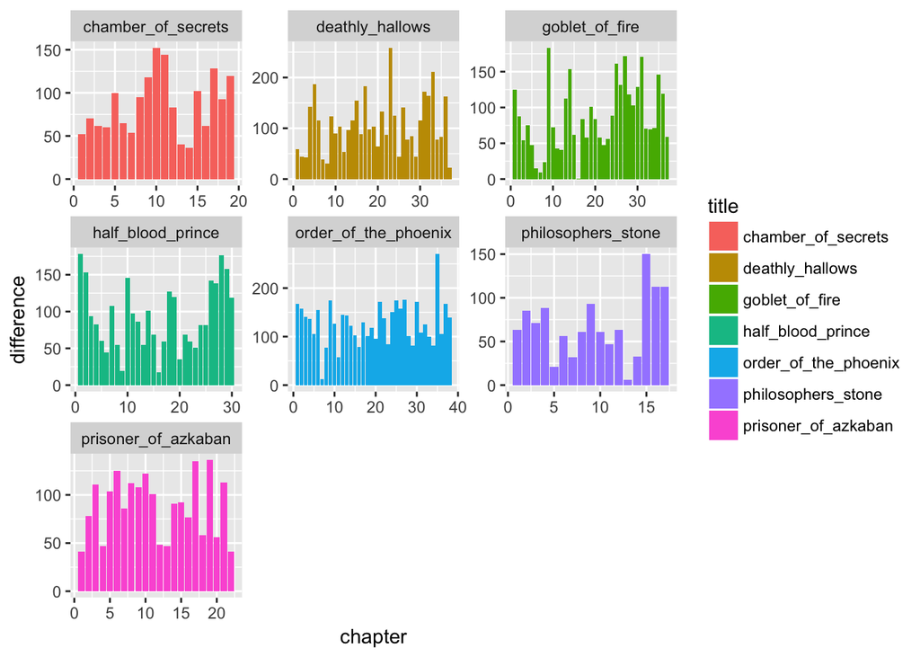

```r
diff
```